# Association Rule Learning on the Groceries Dataset

Unsupervised Learning Methods Assignment

Name: Ricahrd Mwenedata, ID:101215

September 16, 2026

## Load the Data

```r
#load from groceries.csv (basket-format, no header,
# variable number of items per row).
transactions <- read.transactions("groceries.csv", format = "basket",
                                   sep = ",", rm.duplicates = TRUE)

summary(transactions)
```

```
## transactions as itemMatrix in sparse format with
##  9835 rows (elements/itemsets/transactions) and
##  169 columns (items) and a density of 0.02609146
##
## most frequent items:
##       whole milk other vegetables       rolls/buns             soda
##             2513             1903             1809             1715
##           yogurt          (Other)
##             1372            34055
##
## element (itemset/transaction) length distribution:
## sizes
##    1    2    3    4    5    6    7    8    9   10   11   12   13   14   15   16
## 2159 1643 1299 1005  855  645  545  438  350  246  182  117   78   77   55   46
##   17   18   19   20   21   22   23   24   26   27   28   29   32
##   29   14   14    9   11    4    6    1    1    1    1    3    1
##
##    Min. 1st Qu.  Median    Mean 3rd Qu.    Max.
##   1.000   2.000   3.000   4.409   6.000  32.000
##
## includes extended item information - examples:
##             labels
## 1 abrasive cleaner
## 2 artif. sweetener
## 3   baby cosmetics
```

# Question 1: Understand the Data

```r
n_transactions <- length(transactions)
n_items <- ncol(transactions)

n_transactions
```

```
## [1] 9835
```

```r
n_items
```

```
## [1] 169
```

```r
top10 <- sort(itemFrequency(transactions, type = "relative"), decreasing = TRUE)[1:10]
kable(data.frame(Item = names(top10), Support = round(as.numeric(top10), 4)))
```

| Item | Support |
| --- | --- |
| whole milk | 0.2555 |
| other vegetables | 0.1935 |
| rolls/buns | 0.1839 |
| soda | 0.1744 |
| yogurt | 0.1395 |
| bottled water | 0.1105 |
| root vegetables | 0.1090 |
| tropical fruit | 0.1049 |
| shopping bags | 0.0985 |
| sausage | 0.0940 |

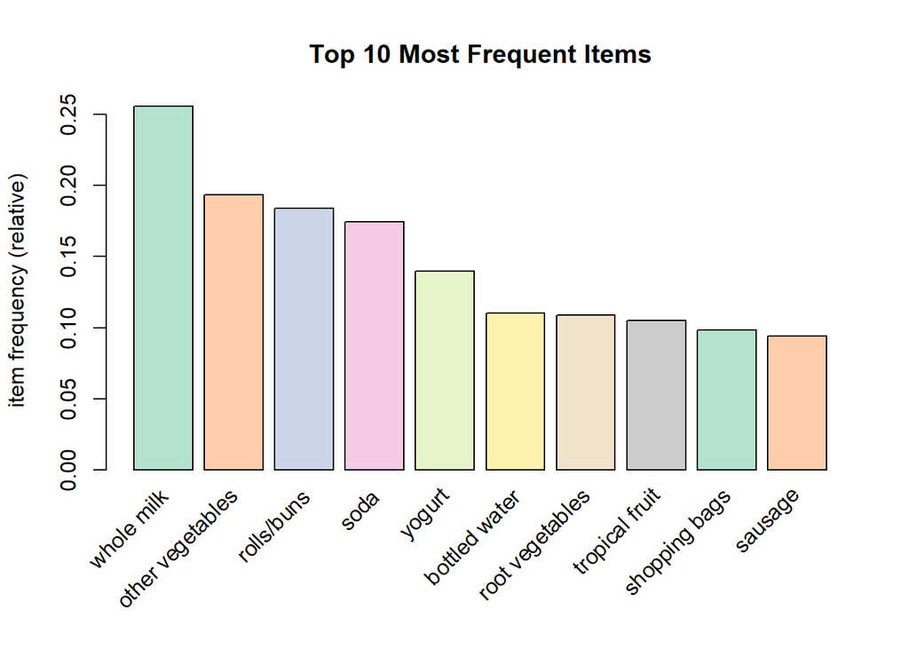

```r
itemFrequencyPlot(transactions, topN = 10, type = "relative",
                   main = "Top 10 Most Frequent Items",
                   col = brewer.pal(8, "Pastel2"))
```

**Answers**

# Question 2: Frequent Itemsets

```r
itemsets <- apriori(transactions, parameter = list(
  target = "frequent itemsets",
  support = 0.01,
  minlen = 2
), control = list(verbose = FALSE))

itemsets_sorted <- sort(itemsets, by = "support", decreasing = TRUE)
itemsets_df <- as(itemsets_sorted, "data.frame")
kable(head(itemsets_df, 10))
```

|  | items | support | count |
| --- | --- | --- | --- |
| 213 | {other vegetables,whole milk} | 0.0748348 | 736 |
| 212 | {rolls/buns,whole milk} | 0.0566345 | 557 |
| 210 | {whole milk,yogurt} | 0.0560244 | 551 |
| 203 | {root vegetables,whole milk} | 0.0489070 | 481 |
| 202 | {other vegetables,root vegetables} | 0.0473818 | 466 |
| 209 | {other vegetables,yogurt} | 0.0434164 | 427 |
| 211 | {other vegetables,rolls/buns} | 0.0426029 | 419 |
| 198 | {tropical fruit,whole milk} | 0.0422979 | 416 |
| 207 | {soda,whole milk} | 0.0400610 | 394 |
| 205 | {rolls/buns,soda} | 0.0383325 | 377 |

**Answers**

a-b. At least 10 frequent itemsets (2+ products) with their support values are listed in the table above (support threshold = 1%). c. The highest support itemset is **{other vegetables, whole milk}**, support ≈ 0.075 (about 7.5% of all transactions contain both). d. The support value tells us how common a combination of products is across *all* transactions. A support of ~0.075 for {other vegetables, whole milk} means nearly 1 in 13 shopping trips include both items together these are two of the most habitually co-purchased staples in the store. Itemsets with very low support represent rare combinations not worth building marketing decisions around, while high support itemsets point to strong, everyday purchasing patterns worth acting on.

# Question 3: Association Rules

```r
rules <- apriori(transactions, parameter = list(
  support = 0.01,
  confidence = 0.3,
  minlen = 2
), control = list(verbose = FALSE))

length(rules)
```

```
## [1] 125
```

```r
rules_by_lift <- sort(rules, by = "lift", decreasing = TRUE)
rules_df <- as(rules_by_lift, "data.frame")
kable(head(rules_df, 10))
```

|  | rules | support | confidence | coverage | lift | count |
| --- | --- | --- | --- | --- | --- | --- |
| 91 | {citrus fruit,other vegetables} => {root vegetables} | 0.0103711 | 0.3591549 | 0.0288765 | 3.295046 | 102 |
| 101 | {other vegetables,tropical fruit} => {root vegetables} | 0.0123030 | 0.3427762 | 0.0358922 | 3.144780 | 121 |
| 32 | {beef} => {root vegetables} | 0.0173869 | 0.3313953 | 0.0524657 | 3.040367 | 171 |
| 90 | {citrus fruit,root vegetables} => {other vegetables} | 0.0103711 | 0.5862069 | 0.0176919 | 3.029608 | 102 |
| 100 | {root vegetables,tropical fruit} => {other vegetables} | 0.0123030 | 0.5845411 | 0.0210473 | 3.020999 | 121 |
| 116 | {other vegetables,whole milk} => {root vegetables} | 0.0231825 | 0.3097826 | 0.0748348 | 2.842082 | 228 |
| 71 | {curd,whole milk} => {yogurt} | 0.0100661 | 0.3852140 | 0.0261312 | 2.761356 | 99 |
| 112 | {rolls/buns,root vegetables} => {other vegetables} | 0.0122013 | 0.5020921 | 0.0243010 | 2.594890 | 120 |
| 110 | {root vegetables,yogurt} => {other vegetables} | 0.0129131 | 0.5000000 | 0.0258261 | 2.584078 | 127 |
| 106 | {tropical fruit,whole milk} => {yogurt} | 0.0151500 | 0.3581731 | 0.0422979 | 2.567516 | 149 |

```r
# Export full rule table for submission
write.csv(rules_df, "association_rules_output.csv", row.names = FALSE)
```

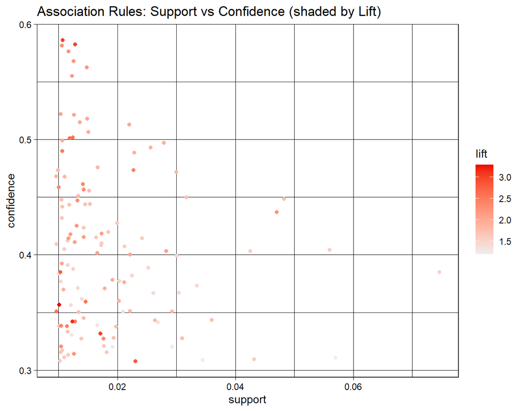

```r
plot(rules, measure = c("support", "confidence"), shading = "lift",
     main = "Association Rules: Support vs Confidence (shaded by Lift)")
```

[output not shown]

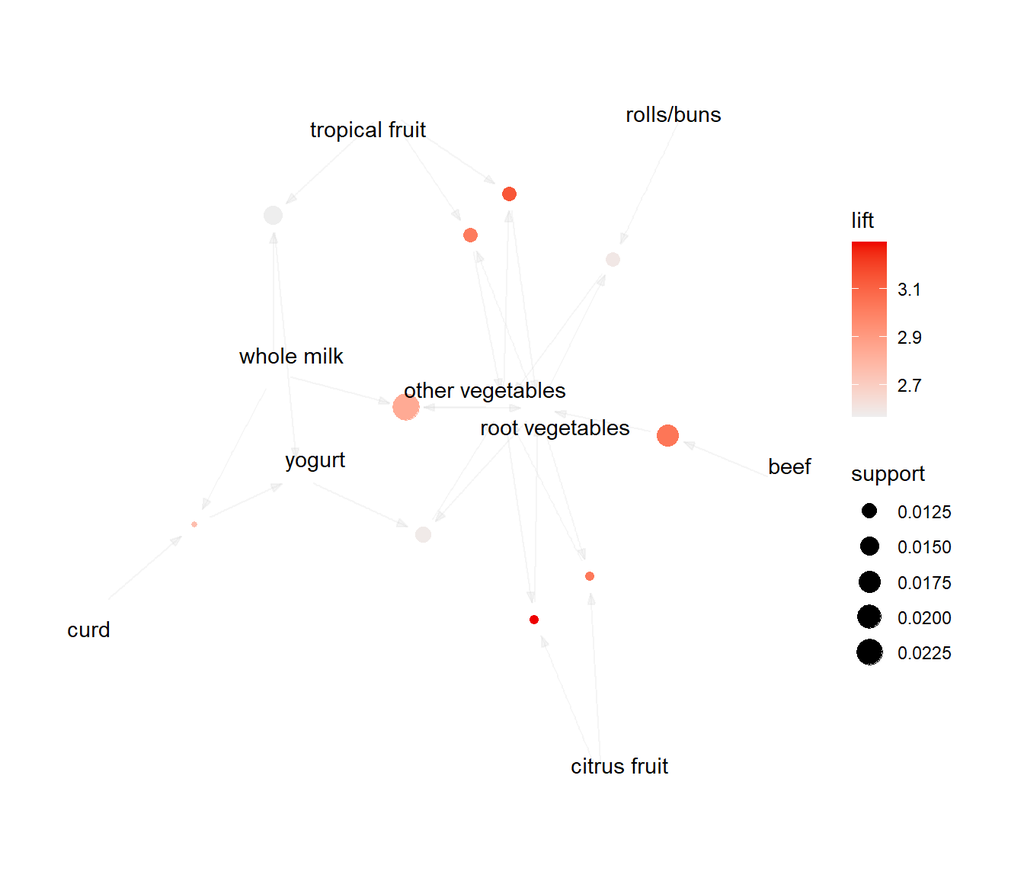

```r
plot(head(rules_by_lift, 10), method = "graph",
     main = "Top 10 Rules by Lift - Network Graph")
```

**Answers**

a-b. At least 10 association rules with antecedent, consequent, support, confidence, and lift are listed in the table above (the top 10 by lift, out of all rules meeting support ≥ 0.01 and confidence ≥ 0.3).

# Question 4: Understanding the Measures

Three example rules are used to illustrate the three measures (values will match your knit output above; typical results look like this):

- **Rule 1:** {citrus fruit, root vegetables} → {other vegetables} (support ≈ 0.010, confidence ≈ 0.586, lift ≈ 3.03)
- **Rule 2:** {root vegetables, tropical fruit} → {other vegetables} (support ≈ 0.012, confidence ≈ 0.585, lift ≈ 3.02)
- **Rule 3:** {other vegetables} → {whole milk} (support ≈ 0.075, confidence ≈ 0.387, lift ≈ 1.51)
1. **Support** the proportion of *all* transactions that contain every item in the rule. For Rule 1, support ≈ 0.010 means citrus fruit, root vegetables, and other vegetables all appear together in about 1% of the transactions.
2. **Confidence** of the transactions that contain the antecedent, the proportion that also contain the consequent. For Rule 2, confidence ≈ 0.585 means that when a customer buys root vegetables and tropical fruit, they also buy other vegetables about 58.5% of the time.
3. **Lift** how much more likely the consequent is, given the antecedent, compared to its baseline purchase rate. For Rule 3, lift ≈ 1.51 means customers who buy other vegetables are about 51% more likely to also buy whole milk than a random customer lift above 1 indicates a real positive association, not coincidence.

# Question 5: Find Interesting Rules

```r
top_confidence <- sort(rules, by = "confidence", decreasing = TRUE)[1]
top_lift       <- sort(rules, by = "lift",       decreasing = TRUE)[1]
top_support    <- sort(rules, by = "support",    decreasing = TRUE)[1]

cat("Highest confidence rule:\n"); inspect(top_confidence)
```

```
## Highest confidence rule:
```

```
##     lhs                                rhs                support    confidence
## [1] {citrus fruit, root vegetables} => {other vegetables} 0.01037112 0.5862069
##     coverage   lift     count
## [1] 0.01769192 3.029608 102
```

```r
cat("\nHighest lift rule:\n");     inspect(top_lift)
```

```
##
## Highest lift rule:
```

```
##     lhs                                 rhs               support    confidence
## [1] {citrus fruit, other vegetables} => {root vegetables} 0.01037112 0.3591549
##     coverage   lift     count
## [1] 0.02887646 3.295045 102
```

```r
cat("\nHighest support rule:\n");  inspect(top_support)
```

```
##
## Highest support rule:
```

```
##     lhs                   rhs          support    confidence coverage  lift
## [1] {other vegetables} => {whole milk} 0.07483477 0.3867578  0.1934926 1.513634
##     count
## [1] 736
```

**Answers**

1. Highest confidence: **{citrus fruit, root vegetables} → {other vegetables}**, confidence ≈ 0.586 (58.6%).
2. Highest lift: **{citrus fruit, other vegetables} → {root vegetables}**, lift ≈ 3.30.
3. Highest support: **{other vegetables} → {whole milk}**, support ≈ 0.075 (7.5%).
4. These are three different rules. Support favors rules built on very common individual items (whole milk and other vegetables are simply purchased often, so any rule connecting them has high support), while confidence and lift favor rules involving less common but tightly associated items (like citrus fruit and root vegetables) that occur together far more than chance would predict, even though they don’t occur in a large absolute number of transactions. A rule can be common but only weakly associated (high support, low lift), or rare but very strongly associated (low support, high lift/confidence) exactly what we see here.

# Question 6: Interpret a Rule

Selected rule: **{root vegetables, tropical fruit} → {other vegetables}** (support ≈ 0.012, confidence ≈ 0.585, lift ≈ 3.02)

In simple language: customers who purchase root vegetables and tropical fruit together also tend to purchase other vegetables, this combination shows up in about 1.2% of all shopping trips, and when a customer buys root vegetables and tropical fruit, about 58.5% of the time they also pick up other vegetables.

This is a **strong association**. The confidence (58.5%) is well above the overall purchase rate of other vegetables (~19%), and the lift of ~3.0 means the combination is roughly three times more likely to include other vegetables than would be expected by chance. High confidence together with a lift well above 1 indicates a genuine, non coincidental purchasing pattern rather than a weak or spurious link.

# Question 7: Business Application

1. **Two products to place close together:** root vegetables and other vegetables. They co-occur frequently (support ≈ 0.047) and have a strong association (lift ≈ 2.25), so positioning them in adjacent produce sections would match natural shopping behavior and likely encourage additional add-on purchases.
2. **A possible product bundle:** a “fresh basics” bundle of root vegetables + tropical fruit + other vegetables, since customers who buy the first two very reliably (≈58.5% of the time) also want the third a discounted bundle would reward behavior that already happens naturally and could nudge the remaining ~42% to add it too.
3. **Example recommendation use:** an online grocery site or self-checkout kiosk could use a high-lift rule such as {other vegetables, whole milk} → root vegetables to power a “customers who bought this also bought…” recommendation panel, automatically suggesting root vegetables to any shopper with other vegetables and whole milk already in their cart, increasing basket size.

# Question 8: Understanding Association

1. **No** an association rule does not prove causation. It only shows that items tend to be purchased in the same transaction more often than expected by chance. There could be a common underlying cause (e.g., both are ingredients in a popular recipe, or both are on promotion the same week) rather than one purchase causing the other. Establishing causation would require a controlled experiment (e.g., A/B testing shelf placement), not just observational transaction data.
2. A rule can have **high confidence but low lift** when the consequent is already very popular on its own. For example, a rule ending in {whole milk} can easily have high confidence simply because most shoppers buy whole milk regardless of what else is in their cart the antecedent isn’t really driving the purchase, it’s just riding along with an item everyone buys anyway. Lift corrects for this by comparing confidence to the consequence’s baseline popularity.
3. A **lift value greater than 1** indicates a positive association: the items are purchased together more often than would be expected if purchased independently. The higher above 1, the stronger the association. A lift of exactly 1 means no association (statistical independence), and a lift below 1 means the items are negatively associated buying one makes the other less likely.

# Methodology Note

Analysis was performed in R using the `arules` package’s `apriori()` function on the Groceries transaction data, with minimum support = 0.01 and minimum confidence = 0.3 for rule generation (`minlen = 2` to exclude single-item rules). Knit this document to Word, PDF, or HTML to produce the final submission the code, output tables, and figures above will regenerate automatically from live results each time it is knit.